# 01 - Gebäudedaten Einlesen, Aufbereiten und Bereinigen

Curdin Derungs

July 2018

# Daten einlesen

## Gebäude der Amtliche Vermessung (AV)

Die Daten der Amtlichen Vermessung werden eingelesen. Die Daten wurden über [ASIT.vd](https://www.asitvd.ch/) bestellt.

```r
#SHP lesen
rolle_build<-readOGR(layer = "MOVD_CAD_TPR_BATHS_S", dsn = paste(dataPath,"11_Cadastre_AmtlVermessung/Cadastre_9719_NO66KX/Cadastre/",sep=""))
#reprojection
rolle_build<-spTransform(rolle_build,CRSobj = CRS("+init=epsg:21781"))

#compute area
areaPoly<-sapply(rolle_build@polygons,function(x){
  x@Polygons[[1]]@area
})

#create id
rolle_build$iid<-1:nrow(rolle_build)
```

In diesem Skript werden alle relevanten Gebäudedaten eingelesen und miteinander verschnitten. Die Gebäudegeometrien werden aus der amtlichen Vermessung und von Open Steet Map (OSM) bezogen. Gebäudeinformationen zu Heizung, Alter, etc. werden aus den GWR Punkten hinzugefügt.

## GWR Punkte

Ebenfalls die GWR Daten für Rolle und MS-Rolle wurden über [ASIT.vd](https://www.asitvd.ch/) bestellt.

```r
##csv lesen
rolle_gwr<-read.csv(paste(dataPath,"02_GWR/Rolle_GEB-02.csv",sep=""),sep = ";",encoding = "Latin-1")
summary(rolle_gwr$GWW2)
```

```
##    Mode    NA's
## logical     894
```

```r
#only existing buildings
rolle_gwr<-rolle_gwr[rolle_gwr$GSTAT==1004,]

#only non-na's
rolle_gwr<-rolle_gwr[!is.na(rolle_gwr$GKODX),]

#no duplicates
rolle_gwr<-rolle_gwr[!duplicated(rolle_gwr$EGID),]

#unique, new id for internal use
rolle_gwr$iid<-1:nrow(rolle_gwr)

#change coordinates of two gwr points after visual analysis in qgis
rolle_gwr[rolle_gwr$EGID==280080732,c("GKODX","GKODY")]<-c(2515260,1146491)
rolle_gwr[rolle_gwr$EGID==280079954,c("GKODX","GKODY")]<-c(2515324,1146476)

#transform gwr to spatial data
coordinates(rolle_gwr)<-~GKODX+GKODY
proj4string(rolle_gwr)<-CRS("+init=epsg:2056")

#reprojection
rolle_gwr<-spTransform(rolle_gwr,CRSobj = CRS("+init=epsg:21781"))

#rolle_gwr<-rolle_gwr[is.na(rolle_gwr$GABBJ),]

#filter/rename attributes
rolle_gwr<-rolle_gwr[,c("EGID","GSTAT","GKAT","GKLAS","GAREA","GASTW","GBAUJ","GANZWHG","GABBJ","GHEIZ","GENHZ","GENWW","GWWV")]


##mont-sur-rolle
ms_rolle_gwr<-readOGR(layer = "OIT_OIT_TPR_RCB_BATIMENT", dsn = paste(dataPath,"02_GWR/mont_sur_rolle_gwr_shp",sep=""))
#only existing buildings
ms_rolle_gwr<-ms_rolle_gwr[ms_rolle_gwr$STATUT_BAT==1004,]

#filter/rename attributes
ms_rolle_gwr<-ms_rolle_gwr[,c("EGID","STATUT_BAT","CATEGORIE","CLASSE","SURFACE","NB_NIV","CONS_ANNEE","NB_LOG","DEMOL_ANNE","CHAUFF_SYS","CHAUFF_AGT","EAU_CHD_AG","EAU_CHD_IN")]
names(ms_rolle_gwr)<-c("EGID","GSTAT","GKAT","GKLAS","GAREA","GASTW","GBAUJ","GANZWHG","GABBJ","GHEIZ","GENHZ","GENWW","GWWV")

#reprojection
ms_rolle_gwr<-spTransform(ms_rolle_gwr,CRSobj = CRS("+init=epsg:21781"))

#combining the two rolle-gwrs
rolle_gwr<-rbind(rolle_gwr,ms_rolle_gwr)

#removing mont-sur-rolle
rm(list=c("ms_rolle_gwr"))
```

## Gebäude von OSM

Hier werden die OSM Gebäudedaten eingelesen. Die Daten werden direkt über die OSM-API bezogen. Der Code ist auskommentiert und es werden aus Gründen der Performanz zwischengespeicherte Daten eingelesen.

```r
# #...OSM gebaeude ueber die API direkt beziehen
#
# #gebaeude von mont-sur-rolle
# q1 <- getbb(place_name = "mont-sur-rolle, switzerland", format_out = "polygon") %>%
#   opq() %>%
#   add_osm_feature(key="building")
#
# out <- osmdata_sp(q1)
# m_s_rolle_build_osm <-  out$osm_polygons
#
# dat<-m_s_rolle_build_osm@data
# for(i in 1:ncol(dat)){attr(dat[,i], "ATT") <- NULL}
# m_s_rolle_build_osm@data<-dat
#
# #gebaeude von rolle
# q1 <- getbb(place_name = "rolle, switzerland", format_out = "polygon") %>%
#   opq() %>%
#   add_osm_feature(key="building")
#
# out <- osmdata_sp(q1)
# rolle_build_osm <-  out$osm_polygons
#
# dat<-rolle_build_osm@data
# for(i in 1:ncol(dat)){attr(dat[,i], "ATT") <- NULL}
# rolle_build_osm@data<-dat
#
# #rolle und ms-rolle zusammenfuehren
# rolle_build_dat<-rbind.fill(rolle_build_osm@data,m_s_rolle_build_osm@data)
#
# rolle_build_osm@data<-data.frame(id=1:nrow(rolle_build_osm))
# m_s_rolle_build_osm@data<-data.frame(id=1:nrow(m_s_rolle_build_osm))
#
# rolle_build_osm<-rbind(rolle_build_osm,m_s_rolle_build_osm)
#
# rolle_build_osm@data<-rolle_build_dat
#
# #speichern
# #create id
# rolle_build_osm$iid<-1:nrow(rolle_build_osm)
#
# #reprojection
# rolle_build_osm<-spTransform(rolle_build_osm,CRSobj = CRS("+init=epsg:21781"))
#
# save(rolle_build_osm,file = "data/osmBuildRolle.Rdata")

#zwischengespeicherte Daten einlesen
load("data/osmBuildRolle.Rdata")
```

# Geometrische Verschneidung

## OSM Geäude die nicht in AV sind

In einem ersten Analyseschritt werden alle OSM Gebäude identifiziert, welche nicht in den AV Daten enthalten sind. Gebäude gelten als OSM Gebäude wenn mehr als 90% ihrer Fläche ausserhalb von AV Gebäuden liegt. Wiederum wird aus Performanzgründen auf ein zwischengespeichertes Ergebnis zugegriffen.

```r
# #getting some info on osm geometries, such as interneal id or area
# rolle_build_osm$areaOrig<-rgeos::gArea(rolle_build_osm,byid=TRUE)
#
# #earasing AV from OSM (computed using st -> much faster!!)
# #might takes a while...
# osm.st <- st_as_sf(rolle_build_osm[,"iid"])
# av.st <- st_as_sf(rolle_build[,"iid"])
# diff <- st_difference(osm.st, st_union(st_combine(av.st)))
#
# #back to sp
# diff.sp <- as(diff, "Spatial")
#
# #making area explicit form cropped osm
# diff.sp$areaCrop<-rgeos::gArea(diff.sp,byid=TRUE)
#
# diff.df<-merge(diff.sp@data,rolle_build_osm@data[,c("iid","areaOrig")],by="iid")
# diff.df$areaDiff<-diff.df$areaCrop/diff.df$areaOrig
#
# diff.sp@data<-merge(diff.sp@data,diff.df,by="iid")
#
# rolle_build_osm_excl<-diff.sp[diff.sp$areaDiff>0.9,]
#
# rolle_build_osm_excl<-spTransform(rolle_build_osm_excl,CRSobj = CRS("+init=epsg:21781"))
#
# save(rolle_build_osm_excl,file = "data/osmBuildRolle_excl.Rdata")
load("data/osmBuildRolle_excl.Rdata")
```

## GWR und AV verscheiden

Nun werden die AV Daten mit den GWR Daten verschnitten. Es handelt sich dabei um eine Verschneidung von Punktdaten (GWR) mit Polygondaten (AV). Dabei kann es zu Mehrdeutigkeiten kommen; ein GWR-Punkt kann auf mehreren Gebäuden liegen oder mehrere GWR-Punkte können auf einem Gebäude liegen.

Hier wird folgendermassen vorgegangen: * In einem ersten Schritt werden die Gebäude extrahiert, welche genau eine Verschneidung von GWR Punkt und AV Polygon haben. * Für die Fälle von “mehreren AV zu einem GWR”" oder “mehreren GWR zu einem AV”" wird jeweils die Kombination ausgewählt, welche übereinstimmende Angaben in Bezug auf die Gebäudefläche enthält (oder die übereinstimmensten, falls keine genaue Übereinstimmung besteht).  
* Übrig bleiben die AV Gebäude ohne GWR Pendant und die GWR Punkte, welche keinem AV Gebäude zugeordnet werden konnten.

```r
#intersecting data

#all data requires a unique identifier
rolle_build$iid<-1:nrow(rolle_build)
rolle_gwr$iid<-1:nrow(rolle_gwr)

#spatial intersection of osm with gwr
#the resulting df contains a list element per osm building
#for each building the intersecting gwr$iid's, if any, are known
ov<-sp::over(rolle_build[,"iid"],rolle_gwr[,"iid"], returnList = TRUE)

#iterating through all lists and retrieve
#osm without gwr buildings: osm_empty
#osm that have one gwr building: osm_ok
#osm that have multiple gwr buildings: osm_mult
bld_empty<-numeric()
bld_ok<-numeric()
bld_mult<-numeric()

#gwr that do not intersect with bld: gwr_empty
#gwr that intersect with one bld: gwr_ok
#gwr that intersect with multiple bld (can happen if bld polygons overlap): gwr_mult
gwr_empty<-numeric()
gwr_ok<-numeric()
gwr_mult<-numeric()

#the two types of intersection - one gwr on one bld & multiple gwr on one bld - are stored in one df with respective iid's
gwr_on_bld_ok<-data.frame(iidbld=NA,iidgwr=NA)
gwr_on_bld_multi<-data.frame(iidbld=NA,iidgwr=NA)

#start iteration
for(i in 1:length(ov)){
  ov.i<-ov[[i]]

  #no gwr in bld
  if(nrow(ov.i)==0){

    bld_empty<-c(bld_empty,i)

    #exactly one gwr in bld
  }else if(nrow(ov.i)==1){

    bld_ok<-c(bld_ok,i)
    gwr_ok<-c(gwr_ok,ov.i$iid)

    gwr_on_bld_ok<-rbind(gwr_on_bld_ok,data.frame(iidbld=i,iidgwr=ov.i$iid))

    #several gwr in one bld
  }else if(nrow(ov.i)>1){

    bld_mult<-c(bld_mult,i)
    gwr_mult<-c(gwr_mult,ov.i$iid)

    gwr_on_bld_multi<-rbind(gwr_on_bld_multi,data.frame(iidbld=rep(i,nrow(ov.i)),iidgwr=ov.i$iid))

  }
}

gwr_on_bld_ok<-gwr_on_bld_ok[-1,]
gwr_on_bld_multi<-gwr_on_bld_multi[-1,]

# gwr_on_bld_multi<-merge(gwr_on_bld_multi,rolle_gwr@data,by.x="iidgwr",by.y="iid")
# gwr_on_bld_multi<-merge(gwr_on_bld_multi,rolle_build@data,by.x="iidbld",by.y="iid")

# rolle_build[rolle_build$iid==12,]
# rolle_gwr[rolle_gwr$iid==1456 | rolle_gwr$iid==1674,]

#there are now still duplicates in terms of gwr points that intersect with multiple buildings
#these duplicates are not resolved at the moment,
#however, they cause that the sum of empty+OK+multiple equals to more than the number of gwr buildings
un<-unique(c(gwr_ok,gwr_mult))
gwr_empty<-rolle_gwr@data[!rolle_gwr$iid%in%un,"iid"]

#randomly removing osm or tlm that recieved multiple gwrs...
#should not be an issue with the new building data
gwr_on_bld_ok_clean<-gwr_on_bld_ok[!duplicated(gwr_on_bld_ok$iidgwr), ]
gwr_on_bld_mult_clean<-gwr_on_bld_multi[!duplicated(gwr_on_bld_multi$iidgwr), ]

#all ok bld polygons
rolle_bld_gwr<-rolle_build[rolle_build$iid%in%gwr_on_bld_ok_clean$iidbld,]
rolle_bld_gwr@data<-left_join(rolle_bld_gwr@data, gwr_on_bld_ok_clean, by = c('iid'='iidbld'))
rolle_bld_gwr@data<-left_join(rolle_bld_gwr@data, rolle_gwr@data, by = c('iidgwr'='iid'))

#and those gwr that did not match with a building
rolle_gwr_empty<-rolle_gwr[rolle_gwr$iid%in%gwr_empty,]

#all bld that have multiple gwr
#note: faced problems with merge()...
gwr_on_bld_mult_clean <- left_join(gwr_on_bld_mult_clean, rolle_gwr@data, by = c('iidgwr'='iid'))

#resolving the one gwr per bld that has most similar area as stored in gwr
gwr_on_bld_mult_clean$GAREA[is.na(gwr_on_bld_mult_clean$GAREA)]<-0
gwr_on_bld_mult_clean$areaTemp<-as.numeric(gwr_on_bld_mult_clean$GAREA)+
  rnorm(n = nrow(gwr_on_bld_mult_clean),mean = 0,sd=1)

gwr_on_bld_mult_clean<-left_join(gwr_on_bld_mult_clean, rolle_build@data[,c("iid","SHAPE_AREA")], by = c('iidbld'='iid'))

gwr_on_bld_mult_clean$areaDiff<-abs(as.numeric(gwr_on_bld_mult_clean$areaTemp)-gwr_on_bld_mult_clean$SHAPE_AREA)

gwr_on_bld_mult_single<-gwr_on_bld_mult_clean %>%
  group_by(iidbld) %>%
  filter(areaDiff == min(areaDiff,na.rm=T))

gwr_on_bld_mult_single$areaDiff<-NULL
gwr_on_bld_mult_single$areaTemp<-NULL

rolle_bld_gwr_mult<-rolle_build[rolle_build$iid%in%gwr_on_bld_mult_single$iidbld,]
rolle_bld_gwr_mult@data<-left_join(rolle_bld_gwr_mult@data, gwr_on_bld_mult_single, by = c('iid'='iidbld'))

rolle_build_av_excl<-rolle_build[!rolle_build$iid%in%gwr_on_bld_mult_single$iidbld,]
rolle_build_av_excl<-rolle_build_av_excl[!rolle_build_av_excl$iid%in%gwr_on_bld_ok$iidbld,]
rolle_build_av_excl<-rolle_build_av_excl[!rolle_build_av_excl$iid%in%gwr_on_bld_mult_single$iidbld,]
```

## (Restliche) GWR mit OSM (!=AV) verscheiden

Die GWR Punkte welche im vorangegangenen Schritt nicht zugeordnet werden konnten, werden nun in gleicher Art und Weise wie oben mit den Gebäuden aus OSM verschnitten (resp. mit den Gebäuden aus OSM, welche nicht in der AV vorkommen).

```r
#all data requires a unique identifier
rolle_build_osm_excl$iid<-1:nrow(rolle_build_osm_excl)
rolle_gwr_empty$iid<-1:nrow(rolle_gwr_empty)

#spatial intersection of osm with gwr
ov<-sp::over(rolle_build_osm_excl[,"iid"],rolle_gwr_empty[,"iid"], returnList = TRUE)

gwr_on_osm<-data.frame(iidosm=NA,iidgwr=NA)
for(i in 1:length(ov)){
  ov.i<-ov[[i]]
  if(nrow(ov.i)==1){
    gwr_on_osm<-rbind(gwr_on_osm,data.frame(iidosm=i,iidgwr=ov.i$iid))
  }
}
gwr_on_osm<-gwr_on_osm[-1,]


rolle_osm_gwr<-rolle_build_osm_excl[rolle_build_osm_excl$iid%in%gwr_on_osm$iidosm,]
rolle_osm_gwr@data<-merge(rolle_osm_gwr@data,gwr_on_osm,by.x="iid",by.y="iidosm")
rolle_osm_gwr@data<-merge(rolle_osm_gwr@data,rolle_gwr_empty@data,by.x="iidgwr",by.y="iid")

rolle_build_osm_excl<-rolle_build_osm_excl[!rolle_build_osm_excl$iid%in%gwr_on_osm$iidosm,]

rolle_gwr_empty<-rolle_gwr_empty[!rolle_gwr_empty$iid%in%gwr_on_osm$iidgwr,]
```

# Gebäudeinformation

## Gebäude Details und manuelle Änderungen

Die Codes aus den GWR Daten werden mit den zugehörigen ausformulierten Attributbeschreibungen ergänzt. Zusätzlich werden ein paar manuelle Änderungen hinzugefügt:  
* das Migros Gebäude ist unterdessen neu gebaut worden (Kombination aus Wohnen und Einkaufen). Die neuen Geometrien mit den entsprechenden Informationen wurden separat im GIS erfasst und werden hier hinzugefügt.  
* ein grosses Gebäude ist teilweise Restaurant und teilweise Industrie. Die beiden Nutzungen werden unterschieden.  
* das Schloss wird manuell hinzugefügt. * alle AV Gebäude mit einer Fläche >150m2, welche nicht in GWR abgebildet sind werden hinzugenommen.

```r
#combine all build. data
rolle_bld_gwr_out<-rolle_bld_gwr[,c("EGID","GSTAT","GKAT","GKLAS","GAREA","GASTW","GBAUJ","GANZWHG","GABBJ","GHEIZ","GENHZ","GENWW","GWWV")]
rolle_bld_gwr_mult_out<-rolle_bld_gwr_mult[,c("EGID","GSTAT","GKAT","GKLAS","GAREA","GASTW","GBAUJ","GANZWHG","GABBJ","GHEIZ","GENHZ","GENWW","GWWV")]
rolle_osm_gwr_out<-rolle_osm_gwr[,c("EGID","GSTAT","GKAT","GKLAS","GAREA","GASTW","GBAUJ","GANZWHG","GABBJ","GHEIZ","GENHZ","GENWW","GWWV")]

rolle_bld_gwr_out$source<-"AVs"
rolle_bld_gwr_mult_out$source<-"AVm"
rolle_osm_gwr_out$source<-"OSM"

rolle_bld_out<-rbind(rolle_bld_gwr_out,rolle_bld_gwr_mult_out,rolle_osm_gwr_out)

##spezielle gebäude
#loading migros building
rolle_migros<-readOGR("data/geom", "rolle_migros_wgs")
rolle_migros<-spTransform(rolle_migros,CRSobj = CRS("+init=epsg:21781"))
rolle_migros<-rolle_migros[,1:13]
rolle_migros$source<-"manual"

rolle_bld_out<-rolle_bld_out[rolle_bld_out$EGID!=280079171,]
rolle_migros$GWWV<-NA
rolle_bld_out<-rbind(rolle_bld_out,rolle_migros)

#loading restaurant building
rolle_resti<-readOGR("data/geom", "rolle_resti01_wgs")
rolle_resti<-spTransform(rolle_resti,CRSobj = CRS("+init=epsg:21781"))
rolle_resti<-rolle_resti[,1:13]
rolle_resti$source<-"manual"

rolle_bld_out<-rolle_bld_out[rolle_bld_out$EGID!=280062591,]
rolle_resti$GWWV<-NA
rolle_bld_out<-rbind(rolle_bld_out,rolle_resti)

#loading restaurant building
rolle_schloss<-readOGR("data/geom", "rolle_schloss_wgs")
rolle_schloss<-spTransform(rolle_schloss,CRSobj = CRS("+init=epsg:21781"))
rolle_schloss@data<-rolle_bld_out@data[1,]
rolle_schloss@data[1,]<-c("9999999",rep(NA,3),round(rolle_schloss@polygons[[1]]@area,0),rep(NA,9))
rolle_schloss$source<-"manual"
rolle_schloss$GWWV<-NA
rolle_bld_out<-rbind(rolle_bld_out,rolle_schloss)

#adding AV (!=GWR)
rolle_av_temp<-rolle_build_av_excl[rolle_build_av_excl$SHAPE_AREA>150,]
rolle_av<-rolle_av_temp
rolle_av@data<-rolle_bld_out@data[1:nrow(rolle_av),]
for(i in 1:nrow(rolle_av)){
  rolle_av@data[i,]<-c(paste("9999_ID",as.character(rolle_av_temp$ID[i]),sep=""),rep(NA,3),round(rolle_av@polygons[[i]]@area,0),rep(NA,9))
}
rolle_av$source<-"AVextra"
rolle_bld_out<-rbind(rolle_bld_out,rolle_av)

#add explicit attribute data...
#but first solving some stange encoding problems (setting encoding in textwrangler to UTF-8 and then changing my settings and using explicit encoding while reading worked...)
Sys.setlocale(category = "LC_ALL", locale = "en_US.UTF-8")
```

```
## [1] "en_US.UTF-8/en_US.UTF-8/en_US.UTF-8/C/en_US.UTF-8/C"
```

```r
gwrCodes<-read.csv("data/gwrCodes.csv",encoding="UTF-8")

names(gwrCodes)[1]<-"id"
rolle_bld_out$GKLAS<-as.numeric(rolle_bld_out$GKLAS)
attrs<-left_join(rolle_bld_out@data, gwrCodes, by = c('GKLAS'='id'))
attrs$fullText<-NULL
names(attrs)[ncol(attrs)]<-"GKLAS_text"

attrs$GHEIZ<-as.numeric(attrs$GHEIZ)
attrs<-left_join(attrs, gwrCodes, by = c('GHEIZ'='id'))
attrs$fullText<-NULL
names(attrs)[ncol(attrs)]<-"GHEIZ_text"

attrs$GENHZ<-as.numeric(attrs$GENHZ)
attrs<-left_join(attrs, gwrCodes, by = c('GENHZ'='id'))
attrs$fullText<-NULL
names(attrs)[ncol(attrs)]<-"GENHZ_text"

attrs$GENWW<-as.numeric(attrs$GENWW)
attrs<-left_join(attrs, gwrCodes, by = c('GENWW'='id'))
attrs$fullText<-NULL
names(attrs)[ncol(attrs)]<-"GENWW_text"

attrs$GKAT<-as.numeric(attrs$GKAT)
attrs<-left_join(attrs, gwrCodes, by = c('GKAT'='id'))
attrs$fullText<-NULL
names(attrs)[ncol(attrs)]<-"GKAT_text"

rolle_bld_out@data<-attrs
```

## Fehlende Werte von Nachbarn “borgen”

```r
# #many attributes have missing values
# #these will all seperatly borrow attributes from their nearest neighbour
# #an attribute "borrowed" indicates where this has happened
# rolle_bld_out$GKLAS_borrowed<-is.na(rolle_bld_out$GKLAS)
# rolle_bld_out$GHEIZ_borrowed<-is.na(rolle_bld_out$GHEIZ)
# rolle_bld_out$GENHZ_borrowed<-is.na(rolle_bld_out$GENHZ)
# rolle_bld_out$GENWW_borrowed<-is.na(rolle_bld_out$GENWW)
rolle_bld_out$GBAUJ_borrowed<-is.na(rolle_bld_out$GBAUJ)
rolle_bld_out$GASTW_borrowed<-is.na(rolle_bld_out$GASTW)
#
# #introducing a function that can retrieve attribute for na's from nearest neighbours that have info
# #the function requires two spdf's (one with na's and one with a's) that only contain the one attribute of interest
getAttrFromNearNeigh<-function(spdf.na, spdf.a){
  #compte a distance matrix na*a
  dists<-spDists(spdf.na,spdf.a,longlat = F)

  #get index of nearest a to each na
  min.ind<-apply(dists,1,which.min)

  #only borrow information from neighbours within distance 100m
  min.ind[diag(dists[,min.ind])>100]<-NA

  #get the info from the nearest neighs
  info.borrowed<-spdf.a@data[min.ind,1]

  return(info.borrowed)
}
#
# ##GKLAS
# #split na from a
# #and only retain attribute of interest
# spdf.na<-rolle_bld_out[is.na(rolle_bld_out$GKLAS_text),"GKLAS_text"]
# spdf.a<-rolle_bld_out[!is.na(rolle_bld_out$GKLAS_text),"GKLAS_text"]
#
# #use function
# rolle_bld_out$GKLAS_text[is.na(rolle_bld_out$GKLAS_text)]<-getAttrFromNearNeigh(spdf.na,spdf.a)
#
# #do it for all other four attributes (w/o too many comments)
# spdf.na<-rolle_bld_out[is.na(rolle_bld_out$GHEIZ_text),"GHEIZ_text"]
# spdf.a<-rolle_bld_out[!is.na(rolle_bld_out$GHEIZ_text),"GHEIZ_text"]
# rolle_bld_out$GHEIZ_text[is.na(rolle_bld_out$GHEIZ_text)]<-getAttrFromNearNeigh(spdf.na,spdf.a)
#
# spdf.na<-rolle_bld_out[is.na(rolle_bld_out$GENHZ_text),"GENHZ_text"]
# spdf.a<-rolle_bld_out[!is.na(rolle_bld_out$GENHZ_text),"GENHZ_text"]
# rolle_bld_out$GENHZ_text[is.na(rolle_bld_out$GENHZ_text)]<-getAttrFromNearNeigh(spdf.na,spdf.a)
#
# spdf.na<-rolle_bld_out[is.na(rolle_bld_out$GENWW_text),"GENWW_text"]
# spdf.a<-rolle_bld_out[!is.na(rolle_bld_out$GENWW_text),"GENWW_text"]
# rolle_bld_out$GENWW_text[is.na(rolle_bld_out$GENWW_text)]<-getAttrFromNearNeigh(spdf.na,spdf.a)
#
spdf.na<-rolle_bld_out[is.na(rolle_bld_out$GBAUJ),"GBAUJ"]
spdf.a<-rolle_bld_out[!is.na(rolle_bld_out$GBAUJ),"GBAUJ"]
rolle_bld_out$GBAUJ[is.na(rolle_bld_out$GBAUJ)]<-getAttrFromNearNeigh(spdf.na,spdf.a)

spdf.na<-rolle_bld_out[is.na(rolle_bld_out$GASTW),"GASTW"]
spdf.a<-rolle_bld_out[!is.na(rolle_bld_out$GASTW),"GASTW"]
rolle_bld_out$GASTW[is.na(rolle_bld_out$GASTW)]<-getAttrFromNearNeigh(spdf.na,spdf.a)
```

# Visualisierung

## Diagramme mit Summary Statistic

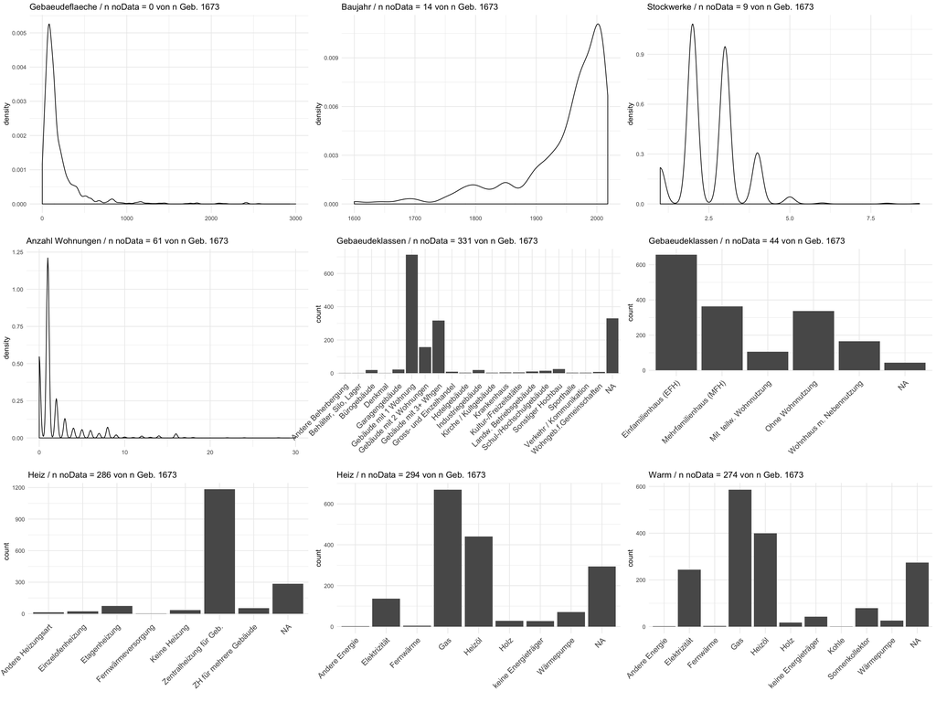

```r
p1<-ggplot(rolle_bld_out@data, aes(x=as.numeric(GAREA)))+
  geom_density(alpha=0.5)+
  theme_minimal()+
  ggtitle(paste("Gebaeudeflaeche / n noData = ",sum(is.na(rolle_bld_out@data$GAREA))," von n Geb. ",nrow(rolle_bld_out),sep=""))+
  xlim(c(0,3000))+
  xlab("")

p2<-ggplot(rolle_bld_out@data, aes(x=as.numeric(GBAUJ)))+
  geom_density(alpha=0.5)+
  theme_minimal()+
  ggtitle(paste("Baujahr / n noData = ",sum(is.na(rolle_bld_out@data$GBAUJ))," von n Geb. ",nrow(rolle_bld_out),sep=""))+
  xlim(c(1600,2018))+
  xlab("")

p3<-ggplot(rolle_bld_out@data, aes(x=as.numeric(GASTW)))+
  geom_density(alpha=0.5)+
  theme_minimal()+
  ggtitle(paste("Stockwerke / n noData = ",sum(is.na(rolle_bld_out@data$GASTW))," von n Geb. ",nrow(rolle_bld_out),sep=""))+
  xlab("")

p4<-ggplot(rolle_bld_out@data, aes(x=as.numeric(GANZWHG)))+
  geom_density(alpha=0.5)+
  theme_minimal()+
  ggtitle(paste("Anzahl Wohnungen / n noData = ",sum(is.na(rolle_bld_out@data$GANZWHG))," von n Geb. ",nrow(rolle_bld_out),sep=""))+
  xlim(c(0,30))+
  xlab("")

p5<-ggplot(rolle_bld_out@data, aes(x=GKLAS_text))+
  geom_bar()+
  theme_minimal()+
  ggtitle(paste("Gebaeudeklassen / n noData = ",sum(is.na(rolle_bld_out@data$GKLAS_text))," von n Geb. ",nrow(rolle_bld_out),sep=""))+
  theme(axis.text.x = element_text(angle = 45, hjust = 1,size=12))+
  xlab("")

p6<-ggplot(rolle_bld_out@data, aes(x=GKAT_text))+
  geom_bar()+
  theme_minimal()+
  ggtitle(paste("Gebaeudeklassen / n noData = ",sum(is.na(rolle_bld_out@data$GKAT_text))," von n Geb. ",nrow(rolle_bld_out),sep=""))+
  theme(axis.text.x = element_text(angle = 45, hjust = 1,size=12))+
  xlab("")

p7<-ggplot(rolle_bld_out@data, aes(x=GHEIZ_text))+
  geom_bar()+
  theme_minimal()+
  ggtitle(paste("Heiz / n noData = ",sum(is.na(rolle_bld_out@data$GHEIZ_text))," von n Geb. ",nrow(rolle_bld_out),sep=""))+
  theme(axis.text.x = element_text(angle = 45, hjust = 1,size=12))+
  xlab("")

p8<-ggplot(rolle_bld_out@data, aes(x=GENHZ_text))+
  geom_bar()+
  theme_minimal()+
  ggtitle(paste("Heiz / n noData = ",sum(is.na(rolle_bld_out@data$GENHZ_text))," von n Geb. ",nrow(rolle_bld_out),sep=""))+
  theme(axis.text.x = element_text(angle = 45, hjust = 1,size=12))+
  xlab("")

p9<-ggplot(rolle_bld_out@data, aes(x=GENWW_text))+
  geom_bar()+
  theme_minimal()+
  ggtitle(paste("Warm / n noData = ",sum(is.na(rolle_bld_out@data$GENWW_text))," von n Geb. ",nrow(rolle_bld_out),sep=""))+
  theme(axis.text.x = element_text(angle = 45, hjust = 1,size=12))+
  xlab("")

p.all<-grid.arrange(p1,p2,p3,p4,p5,p6,p7,p8,p9,ncol=3)
```

```r
p.all
```

## Kartographie

Es bleibt nur noch, die Gebäude in einer Karte darzustellen und anschliessend alle Gebäudedaten zu speichern.

```r
#erst alle daten in wgs projezieren fuer leaflet projektion
rolle_build.wgs<-spTransform(rolle_build,CRSobj = CRS("+init=epsg:4326"))
rolle_av.wgs<-spTransform(rolle_av,CRSobj = CRS("+init=epsg:4326"))

rolle_bld_out.wgs<-spTransform(rolle_bld_out,CRSobj = CRS("+init=epsg:4326"))

rolle_build_osm_excl.wgs<-spTransform(rolle_build_osm_excl,CRSobj = CRS("+init=epsg:4326"))
rolle_build_av_excl.wgs<-spTransform(rolle_build_av_excl,CRSobj = CRS("+init=epsg:4326"))

rolle_gwr.wgs<-spTransform(rolle_gwr,CRSobj = CRS("+init=epsg:4326"))
rolle_gwr_empty.wgs<-spTransform(rolle_gwr_empty,CRSobj = CRS("+init=epsg:4326"))

#visualisierung mit leaflet
m <- leaflet() %>%

  addProviderTiles(providers$Stamen.TonerLite, group = "OSM (b/w)") %>%
  addProviderTiles(providers$OpenStreetMap, group = "OSM") %>%
  addProviderTiles("Esri.WorldImagery", group = "ESRI") %>%

  addPolygons(data=rolle_build.wgs,
              stroke = TRUE,
              fillOpacity = 0.4,
              color = "grey",
              opacity = 1,
              weight=1,
              fillColor = "grey",
              popup=rolle_build.wgs$areaPoly,
              group = "Haeuser (AV)")%>%

  addPolygons(data=rolle_build_osm_excl.wgs,
              stroke = TRUE,
              fillOpacity = 0.4,
              color = "orange",
              opacity = 1,
              weight=1,
              fillColor = "orange",
              group = "Haeuser (OSM, kein match)")%>%

    addPolygons(data=rolle_av.wgs,
              stroke = TRUE,
              fillOpacity = 0.4,
              color = "yellow",
              opacity = 1,
              weight=1,
              fillColor = "yellow",
              popup=rolle_av$EGID,
              group = "Haeuser (AV, kein match)")%>%

    addCircles(data=rolle_gwr.wgs,
              color = "grey",
              radius=5,
              group = "GWR (Alle)",
             popup = as.character(rolle_gwr.wgs$iid))%>%

  addPolygons(data=rolle_bld_out.wgs,
              stroke = TRUE,
              fillOpacity = 0.4,
              color = "green",
              opacity = 1,
              weight=1,
              fillColor = "green",
              popup=rolle_bld_out.wgs$sia,
              group = "Rolle Buildings")%>%

    addCircles(data=rolle_gwr_empty.wgs,
              color = "red",
              radius=5,
              group = "GWR (kein match)")%>%

  addLayersControl(
    baseGroups = c("OSM (b/w)", "OSM","ESRI"),
    overlayGroups = c("Haeuser (AV)",
                      "Haeuser (OSM, kein match)",
                      "Haeuser (AV, kein match)",
                      "GWR (Alle)",
                      "Rolle Buildings",
                      "GWR (kein match)"),
    options = layersControlOptions(collapsed = F)
  )%>%
  hideGroup(c("Haeuser (AV)",
                      "Haeuser (OSM, kein match)",
                      "GWR (Alle)",
              "Rolle Buildings (no sia)"))

#leaflet karte ausführen
m
```

[interactive chart not shown]

## Resultate speichern

Alle wichtigen Informationen werden abschliessend gespeichert…

```r
#html karte speichern
wd<-getwd()
htmlwidgets::saveWidget(m, file=paste(wd,"/output/01_output/map/01_map.html",sep=""),selfcontained = T)

#buildings speichern
save(rolle_bld_out,file="output/01_output/geom/01_rolle_bld_out.Rdata")
save(rolle_build_av_excl,file="output/01_output/geom/01_rolle_bld_av_notGwr.Rdata")

writeOGR(rolle_bld_out, "output/01_output/geom", "01_rolle_bld_out", driver="ESRI Shapefile",overwrite_layer = T)
writeOGR(rolle_bld_out.wgs, "output/01_output/geom", "01_rolle_bld_out_wgs", driver="ESRI Shapefile",overwrite_layer = T)
writeOGR(rolle_build_av_excl.wgs, "output/01_output/geom", "01_rolle_bld_av_notGwr_wgs", driver="ESRI Shapefile",overwrite_layer = T)

#abbildungen speichern
ggsave(p.all,filename = "output/01_output/viz/01_buildingPlots.png",dpi = 500,width = 22,height = 15)
```